# Endogenous Macrodynamics in Algorithmic Recourse

IEEE Conference on Secure and Trustworthy Machine Learning

Patrick Altmeyer

Delft University of Technology

Delft University of Technology

[**Patrick Altmeyer**](https://www.patalt.org/)

Giovan Angela

Aleksander Buszydlik

Karol Dobiczek

Arie van Deursen

Cynthia C. S. Liem

November 4, 2026

## Background

**Counterfactual Explanation** (CE) explain how inputs into a model need to change for it to produce different outputs.

Provided the changes are realistic and actionable, they can be used for **Algorithmic Recourse** (AR) to help individuals who face adverse outcomes.

## Example: Consumer Credit

In Figure 1, arrows indicate changes from factuals (loan denied) to counterfactuals (loan supplied).

[figure not shown]

Figure 1: Counterfactuals for Give Me Some Credit dataset (Kaggle 2011).

## Our work in a nutshell …

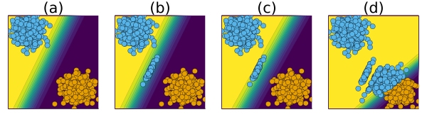

Figure 2: Dynamics in Algorithmic Recourse.

- We show that counterfactuals can induce substantial domain and model shifts like in Figure 2.
- We propose a novel perspective on AR that explicitly addresses this issue.
- We open-source a `Julia` package to study the dynamics we point to.

## Proof-of-Concept

[figure not shown]

Figure 3: A bank has trained a model to evaluate credit applicants. Credit risk is highest in bottom-right corner.

[figure not shown]

Figure 4: The bank has provided recourse to unsuccessful applicants: endogenous domain shift.

[figure not shown]

Figure 5: The bank has retrained the classifier: endogenous model shift.

[figure not shown]

Figure 6: The outcome after the process has been repeated a few times. Average default risk has increased.

## Questions …

- Who should bear the cost?
- Are the counterfactuals genuinely valid in practice?
- What about fairness and privacy concerns?

[figure not shown]

Figure 7: Indiviudals who received recourse are clearly distinguishable.

# Experiments

## Empirical Setup

**Evaluation**: we propose metrics to measure domain shifts and model shifts.

**Models**: we use linear classifiers, deep neural networks and deep ensembles.

**Data**:

##### Synthetic

- Overlapping, Linearly Separable, Circles, Moons.

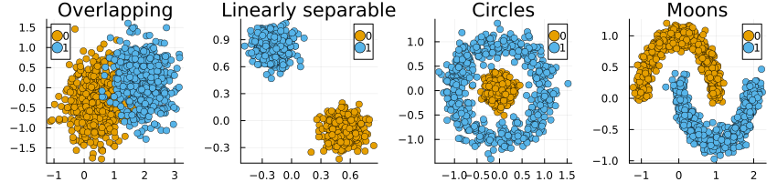

##### Real-World

- Give Me Some Credit (Kaggle 2011), UCI defaultCredit (Yeh and Lien 2009), California Housing

**Generators**: Wachter (Wachter et al. 2017), REVISE (Joshi et al. 2019), DiCE (Mothilal et al. 2020), Greedy (Schut et al. 2021)

## Principal Findings — Synthetic

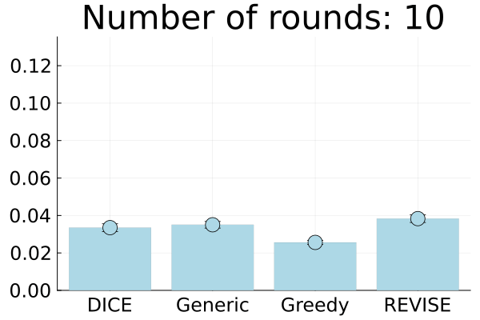

Domain shifts for overlapping synthetic data using deep ensemble.

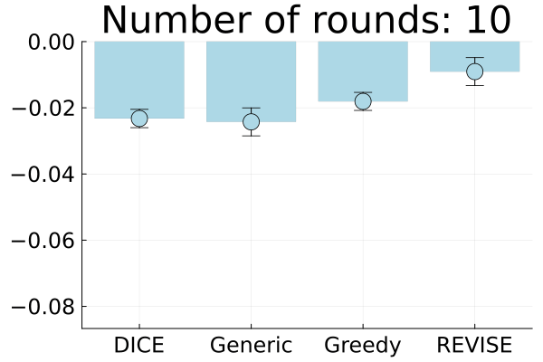

Performance deterioration for overlapping synthetic data using deep ensemble.

## Principal Findings — Real-World

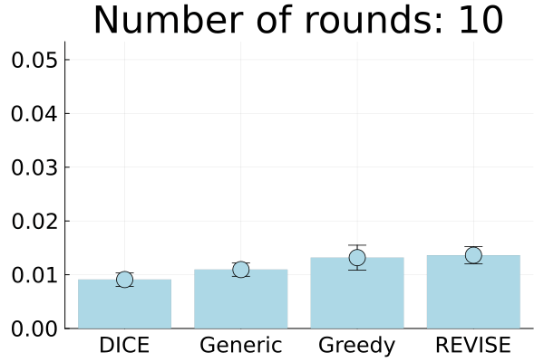

Model shifts for Credit Default data using deep ensemble.

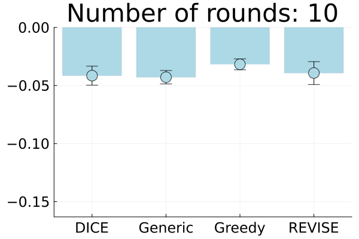

Performance deterioration for Credit Default data using deep ensemble.

# Gradient-Based Recourse Revisited

## From Individual Recourse …

Many existing approaches to CE and AR work with the following baseline:

$$\begin{aligned}
\color{lightgrey} \mathbf{s}^\prime &\color{lightgrey}= \arg \min_{\mathbf{s}^\prime \in \mathcal{S}} \{ {\text{yloss}(M(f(\mathbf{s}^\prime)),y^*)} \\&\color{black} + \lambda {\text{cost}(f(\mathbf{s}^\prime)) } \color{lightgrey} \}
\end{aligned}
\tag{1}$$

Typically concern has centred around minimizing costs to a single individual.

## … towards collective recourse

We propose to extend Equation 1 as follows:

$$\begin{aligned}
\color{lightgrey}\mathbf{s}^\prime &\color{lightgrey}= \arg \min_{\mathbf{s}^\prime \in \mathcal{S}} \{ {\text{yloss}(M(f(\mathbf{s}^\prime)),y^*)} \\ &\color{lightgrey}+ \lambda_1 {\text{cost}(f(\mathbf{s}^\prime))} + \color{black}\lambda_2 {\text{extcost}(f(\mathbf{s}^\prime))} \color{lightgrey}\}
\end{aligned}
\tag{2}$$

The newly introduced term $\text{extcost}(f(\mathbf{s}^\prime))$ is meant to explicitly capture **external costs** generated by changes to $\mathbf{s}^\prime$.

## Background: Externalities

We borrow the concept of private vs. external costs from Economics.

[figure not shown]

Figure 8: Illustration of a negative externality. Source: [Investopedia](https://www.investopedia.com/terms/e/externality.asp).

## Externalities in our Context

Relating this bank to our opening example, the external cost is carried by the retail bank.

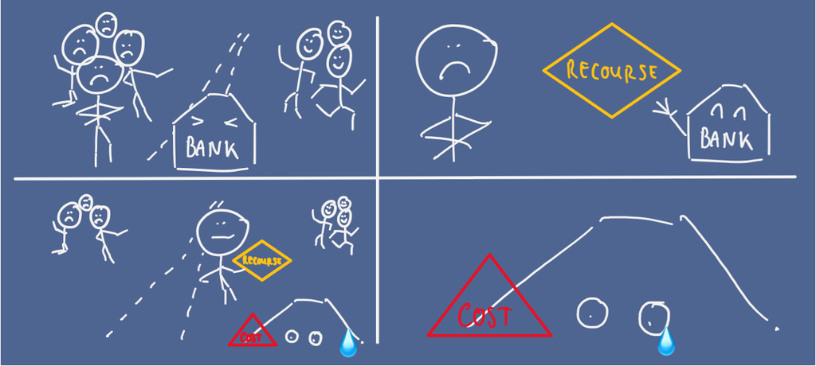

Figure 9: External cost is carried by bank.

## Mitigation Strategies

1. More Conservative Decision Thresholds
2. Classifier Preserving ROAR (ClaPROAR)<sup>1</sup>
3. Gravitational Counterfactual Explanations

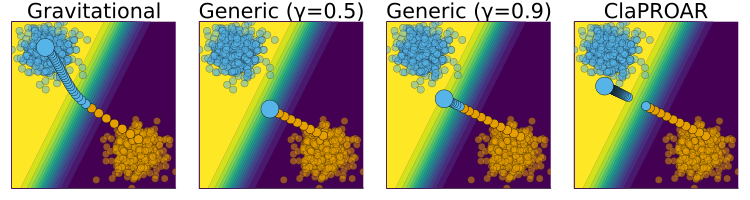

Figure 10: Mitigation strategies.

[^1]: Loosely inspired by ROAR (Upadhyay et al. 2021)

## Secondary Findings

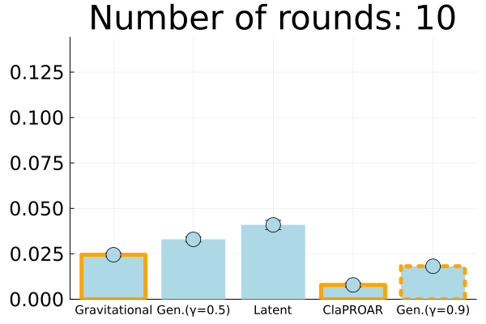

Domain shifts for overlapping synthetic data using deep ensemble.

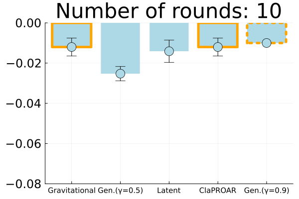

Performance deterioration for overlapping synthetic data using deep ensemble.

# Discussion

## Key Takeaways 🔑

- State-of-the-art approaches to AR induce substantial domain and model shifts.
- External costs of Individual Recourse should be shared across stakeholders.
- Ad-hoc solution: penalize external costs in the counterfactual search objective function (Equation 2).
- This gives rise to interesting cross-disciplinary research ideas (e.g. Pareto-optimal AR).

## Counterfactual Explanations and Probabilistic Machine Learning

> Methodologies and open-source tools that help researchers and practitioners assess the trustworthiness of predictive models.

##### Towards Trustworthy AI in `Julia`

1. [`CounterfactualExplanations.jl`](https://github.com/juliatrustworthyai/CounterfactualExplanations.jl) (JuliaCon 2022)
2. [`ConformalPrediction.jl`](https://github.com/juliatrustworthyai/ConformalPrediction.jl) (JuliaCon 2023 — I hope!)
3. [`LaplaceRedudx.jl`](https://github.com/juliatrustworthyai/LaplaceRedux.jl) (JuliaCon 2022)
4. [`AlgorithmicRecourseDynamics.jl`](https://github.com/juliatrustworthyai/AlgorithmicRecourseDynamics.jl)

… contributions welcome! 😊

[figure not shown]

## 📚 More Reading

- Granular results for all of our experiments can be found in this online companion: https://www.patalt.org/endogenous-macrodynamics-in-algorithmic-recourse/.
- Many other related posts on my blog.

## Image Sources

- Copyright for stock images belongs to TU Delft.
- All other images, graphics or animations were created by us.

## References

Joshi, Shalmali, Oluwasanmi Koyejo, Warut Vijitbenjaronk, Been Kim, and Joydeep Ghosh. 2019. *Towards Realistic Individual Recourse and Actionable Explanations in Black-Box Decision Making Systems*. https://arxiv.org/abs/1907.09615.

Kaggle. 2011. *Give Me Some Credit, Improve on the State of the Art in Credit Scoring by Predicting the Probability That Somebody Will Experience Financial Distress in the Next Two Years.* Https://www.kaggle.com/c/GiveMeSomeCredit; Kaggle. https://www.kaggle.com/c/GiveMeSomeCredit.

Mothilal, Ramaravind K, Amit Sharma, and Chenhao Tan. 2020. “Explaining Machine Learning Classifiers Through Diverse Counterfactual Explanations.” *Proceedings of the 2020 Conference on Fairness, Accountability, and Transparency*, 607–17. https://doi.org/10.1145/3351095.3372850.

Schut, Lisa, Oscar Key, Rory McGrath, et al. 2021. “Generating Interpretable Counterfactual Explanations By Implicit Minimisation of Epistemic and Aleatoric Uncertainties.” *International Conference on Artificial Intelligence and Statistics*, 1756–64.

Upadhyay, Sohini, Shalmali Joshi, and Himabindu Lakkaraju. 2021. “Towards Robust and Reliable Algorithmic Recourse.” *Advances in Neural Information Processing Systems* 34: 16926–37.

Wachter, Sandra, Brent Mittelstadt, and Chris Russell. 2017. “Counterfactual Explanations Without Opening the Black Box: Automated Decisions and the GDPR.” *Harv. JL & Tech.* 31: 841. https://doi.org/10.2139/ssrn.3063289.

Yeh, I-Cheng, and Che-hui Lien. 2009. “The Comparisons of Data Mining Techniques for the Predictive Accuracy of Probability of Default of Credit Card Clients.” *Expert Systems with Applications* 36 (2): 2473–80. https://doi.org/10.1016/j.eswa.2007.12.020.